# GDPR, Data Science, and the Future of Personal Data Regulation

Travis Greene

8/8/2019

# 1 GDPR as a Litmus Test

The GDPR represents the first attempt by a major political body to grapple with the broader social, political, legal consequences of digital technology. It is also the first and most notable attempt by a modern democracy to consciously direct the impact and application of new and transformative technologies. Finally, the GDPR is the first theoretically international regulation (i.e., with jurisdiction beyond just the EU), as opposed to the earlier Directive, and the privacy framework promoted by the Asia Pacific Economic Cooperation area, APEC. The GDPR’s top-down approach contrasts with other recent attempts of companies at self-regulation (e.g., Facebook’s internal ethical committee), and proposals for organizational structures across industry and academia (Tene and Polonetsky 2016; King and Persily 2018).

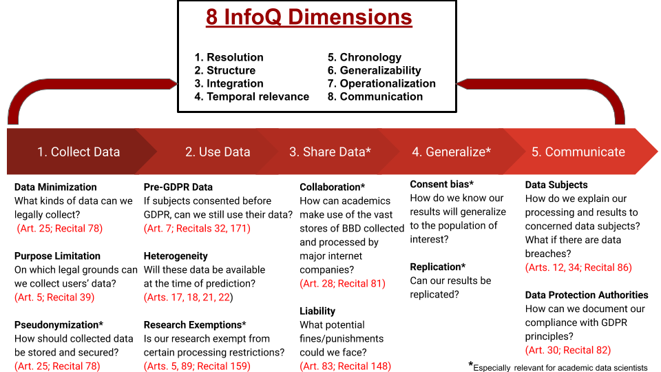

Figure 1.1: Analyzing the GDPR’s Impact on Data Science Workflows using InfoQ

Governments around the world are looking at the GDPR as a litmus test for determining whether it is possible to safely rein in the juggernaut of digital technology. On a fundamental level, the issue underlying the creation of the GDPR is: Can social and political values successfully dictate the application of new technologies, or will new technologies dictate our social and political values? The technology ethicist Van Den Hoven (2012), for example, writes that “a debate on the future values of living is necessary.” And the historian Yuval Noah Harari claims that the most important political question of our time is: “How do you regulate the ownership of data?” (Harari 2018). The GDPR represents just one participant, albeit the loudest and most outspoken, in that global debate. It attempts to answer Harari’s question by positing fundamental human rights to privacy and balancing the economic benefits of personalized predictions and automated decision-making with their potential social costs.

# 2 Implications for Democratic Processes

Because personal data processing, analysis, and modeling have become so embedded into modern day life, it is imperative that data scientists understand what is at stake, and why in 2018 and beyond governments feel the need to pass legislation to regulate their effects. Hosanagar (2019) details the many ways in which algorithms increasingly affect our day-to-day lives. From finding dates, to discovering new music, to deciding which stories appear in our algorithmically-curated news feeds, we nevertheless tend to underestimate the impact of algorithmic design choices on our decisions. What appears to be the result of our free will is in fact the result of a subtle nudge towards this or that. For every option shown to us via algorithmic recommendation, hundreds, thousands–even millions–of potentially relevant items are excluded. Ordinary users of platforms and services driven by algorithmic recommendations would scarcely pause to think about what *might have* been recommended or presented to us, but was not. Hosanagar (2019) ultimately concludes that Americans and others in countries without adequate personal data protections should press their leaders for an Algorithmic Bill of Rights.

Indeed, the very foundations of our political systems are beginning to be affected by algorithmic decision-making. Diakopoulos (2016) implores us to “start asking questions about the degree to which such curation and ranking systems can affect democratic processes.” Taken to the extreme and aggregated over millions of users, these seemingly minor nudges can make behavior ever more predictable and amenable to further algorithmic prediction. Zuboff (2019) views this development as a “challenge to the elemental right to the future tense, which accounts for the individual’s ability to imagine, intend, promise, and construct a future.” The GDPR, with its focus on algorithmic profiling and decision-making, attempts to tackle this issue head-on by providing specific rights to data subjects related to transparency and human-intervention.

# 3 Philosophical Implications: Free-will and Autonomy

We have gradually become so dependent on the results of algorithms that some have argued that philosophical notions of free-will, freedom, and agency need to be reexamined. For example, in the *capabilities* approach to human welfare developed in Sen (1992) and Nussbaum (2011), one’s capability to freely choose something is inherently valuable, even if the result of such a choice is no different from situations in which no free choice is made. When algorithmic decisions rob us of our capability to make free choices, we lose an inherently valuable aspect of human welfare. It is in this sense that Sen and Nussbaum might argue that handing more and more of our mundane life-decisions over to algorithms reduces our freedom and agency: instead of acting on what *we ourselves* value, we are instead forced to act on what the designers of the algorithm value–and in many cases these values reflect an economic logic founded on the singular goal of maximizing “click through rates” and “user engagement” metrics. To this end, the GDPR forces organizations to be transparent about when and how they use algorithmic profiling to provide recommendations or make predictions based on a user’s behavioral data.

# 4 Engineering Accountability: Rise of the Technochauvinists

The irony of the technochauvinists’[^1] position, however, is that it is precisely because of these political, legal, and social systems that technologists can build their technology. They are the giants’ shoulders on which the technologists stand. It is no accident that Google, for instance, was created in the United States and not in Sudan or Afghanistan: without appropriate levels of public safety, access to education, and freedom from violence, it is difficult to convince groups of people to devote themselves to the optimization of Internet search results. The relatively exalted position technologists currently enjoy in society obligates them to, at the very least, consider how the products they create will affect it. The GDPR rightfully encourages this kind of thinking.

# 5 Personal Data and the Emergence of Surveillance Capitalism

We would be naive to believe that technology can be disentangled from the economic system in which it arose. Zuboff (2019), citing the great German sociologist Max Weber, writes that “Economic ends… are always intrinsic to technology’s development and deployment.” In other words, technology does not appear in a vacuum, and applications of technology are dictated by broader forces prevailing in society. The interesting thing about these new forms of digital technology is that they have paved the way for new models of economic value, whereby human experience is viewed as the “free raw material for translation into behavioral data,” something Zuboff (2019) refers to as *surveillance capitalism*. No one could have predicted that the actions of just a handful of technology companies in Silicon Valley could set in motion such a fundamental economic shift. Yet through an accumulation of decisions made by a menagerie of (mostly white male[^2]) corporate managers and data scientists, such a system was eventually created, and now dominates the modern digital economy. Were GDPR in effect 20 years earlier, the seeds of surveillance capitalism could not have been so firmly planted.

This is not to say that technologies such as BBD, machine learning, and automated profiling have not benefited society in untold ways. They clearly have. Business processes and logistics are more efficient than ever. Combined with the Internet of Things (IOT), machine learning is poised to revolutionize the way students are educated, diseases are stopped, new drugs are discovered and terrorists are caught, among many other things. As long as there are enough data scientists and machine learning researchers willing to ask *why* and not just *how*, these new technologies can be a major force for positive change in the world.

# 6 The Need for Data Science Ethics Education

Educating data scientists about GDPR and its key principles is a good first step in closing the gap between STEM fields–where researchers tend to see themselves as dealing with “systems and math, not people”– and the social sciences, which have a long history of human subjects research ethics protocols (Metcalf and Crawford 2016). To be fair, legislating is not easy and technology evolves at an ever-increasing pace, making technological regulation at times resemble a frenzied game of whack-a-mole. But we can no longer afford to let the Googles and Facebooks define the private sphere or determine what constitutes free speech. As one of the founding data scientists at LinkedIn, Jeff Hammerbacher, lamented, “The best minds of my generation are thinking about how to make people click ads (Wu 2017).” If the GDPR is at all successful, it will force data scientists to re-think their data collection, storage, and processing practices from the point of view of privacy-concerned data subjects, and ask themselves whether any potential privacy risks are truly outweighed by benefits to business and society.

# 7 A Public Debate on the Social Role of Technology

Ultimately, whether we wish to enter into this phase of economic system of surveillance capitalism, dominated by attention merchants and automated prediction machines, ought to be left up to us and not remain, as Van Den Hoven (2012) remarks, “confined to the corporate initiative.” By refusing to question the narrative of the technologists and technochauvinists–that the solution to nearly every problem is the application of more technology–we will slowly but surely continue to be subjected to novel, yet undeniably creepy technologies. In the absence of conscious determination about the future role of technology in society, consumers will be left defenseless against myriad forms of privacy lurch. The only solution is a new social contract that outlines the appropriate role of technology in society. This sentiment about the necessity of democratic self-determination in the digital age is echoed by the legal scholar Wu (2017), who writes:

> We must first acknowledge the preciousness of our attention and resolve not to part with it as cheaply or unthinkingly as we so often have. And then we must act, individually and collectively, to make our “attention our own again, and so reclaim ownership of the very experience of living.”

The good news is that the principles embodied in the GDPR, such as the importance of consent and data minimization, appear to be spreading around the globe, even in places historically seen as antithetical to digital privacy. China’s recent Cyber Security Law (CSL) may soon be amended to include provisions that “mandate an opt-out for all personalised content, including news and targeted advertising.”[^3] If these changes are introduced, then Chinese citizens may have more protection against privacy lurch than Americans.

# 8 Rearranging Economic Incentives: Platform Cooperativism

At the same time, new business models that are opposed to the economic logic of surveillance capitalism are being developed and tested. Designed specifically for the digital era, *platform cooperativism* embraces a fundamental shift in the legal, social, and economic goals of Internet-based companies. Platform cooperativism proposes that digital platforms be democratically-governed and owned and orient themselves towards benefiting their community of users–and society more generally–rather than maximize shareholder value in the short-term. For example, charging excessive fees to the platform’s users would make no sense because these fees would ultimately be paid back to the platform owners in the form of dividends (Scholz and Schneider 2017). Whereas in the current system, venture capitalists and investment bankers hope to achieve immense profit through an IPO or acquisition, resulting in the rise of surveillance capitalism, platform cooperativism instead seeks to “harvest, circulate, and recycle the value again and again” for the collective good of its users and owners (Scholz and Schneider 2017). Platform cooperativism thus reimagines the purpose of the organization and prioritizes the welfare of the end users, reminiscent of the way in which the GDPR asks data controllers to prioritize the privacy rights of data subjects over business interests.

# 9 Regulating Algorithms: Algorithmic Task Forces

Finally, as the application of algorithmic decision-making becomes increasingly entrenched in our lives, we will need new institutions and procedures beyond the GDPR. Shneiderman (2016) offers several models of regulation–drawn from analogous experiences in other domains– that could augment the provisions of GDPR. These include planning oversight committees, continuous monitoring by algorithm review boards, and retrospective analyses of algorithmic disasters, similar to those used in the airline industry when an accident occurs. These proposals are a good start, but not all regulation must be done at the national level. Another option is for city and state governments to create “algorithm task forces” similar to the one in New York City that could provide oversight and monitoring of automated decision-making in the public sphere.

Merging national regulation, such as the GDPR, with alternative governance models such as platform cooperativism, with state and local review algorithmic review boards could be a viable solution to the question Harari (2018) views as one of the most important of our time: “How do you regulate the ownership of data?”

Broussard, Meredith. 2018. *Artificial Unintelligence: How Computers Misunderstand the World*. MIT Press.

Diakopoulos, Nicholas. 2016. “Accountability in Algorithmic Decision Making.” *Communications of the ACM* 59 (2): 56–62.

Harari, Yuval Noah. 2018. *21 Lessons for the 21st Century*. Random House.

Hosanagar, Kartik. 2019. *A Human’s Guide to Machine Intelligence: How Algorithms Are Shaping Our Lives and How We Can Stay in Control.* Viking.

King, Gary, and Nate Persily. 2018. “A New Model for Industry-Academic Partnerships.”

Metcalf, Jacob, and Kate Crawford. 2016. “Where Are Human Subjects in Big Data Research? The Emerging Ethics Divide.” *Big Data & Society* 3 (1): 2053951716650211.

Nussbaum, Martha C. 2011. *Creating Capabilities*. Harvard University Press.

Quinn, Michael J. 2006. “On Teaching Computer Ethics Within a Computer Science Department.” *Science and Engineering Ethics* 12 (2): 335–43.

Scholz, Trebor, and Nathan Schneider. 2017. *Ours to Hack and to Own: The Rise of Platform Cooperativism, a New Vision for the Future of Work and a Fairer Internet*. OR books.

Sen, Amartya. 1992. *Inequality Reexamined*. Clarendon Press.

Shneiderman, Ben. 2016. “Opinion: The Dangers of Faulty, Biased, or Malicious Algorithms Requires Independent Oversight.” *Proceedings of the National Academy of Sciences* 113 (48): 13538–40.

Spradling, Carol, Leen-Kiat Soh, and Charles Ansorge. 2008. “Ethics Training and Decision-Making: Do Computer Science Programs Need Help?” *ACM SIGCSE Bulletin* 40 (1): 153–57.

Tene, Omer, and Jules Polonetsky. 2016. “Beyond Irbs: Ethical Guidelines for Data Research.” *Washington and Lee Law Review Online* 72 (3): 458.

Van Den Hoven, Jeroen. 2012. “"Fact Sheet-Ethics Subgroup Iot-Version 4.0.".” Technical Report.

Wu, Tim. 2017. *The Attention Merchants: The Epic Scramble to Get Inside Our Heads*. Vintage.

Zuboff, Shoshana. 2019. *The Age of Surveillance Capitalism: The Fight for the Future at the New Frontier of Power*. Profile Books.

[^1]: Broussard (2018) explains technochauvinism as, “an unwavering faith that if the world just used more computers, and used them properly, social problems would disappear and we’d create a digitally enabled utopia.”
[^2]: https://ainowinstitute.org/discriminatingsystems.pdf
[^3]: www.channelnewsasia.com/news/commentary/china-great-leap-forward-in-data-protection-11429624